# Cyclistic Case Study - Visualizations

Brian Rosseau

2023-07-15

### 1. Load cleaned data set and packages

### 2. Most popular stations

#### All stations, by number of rides

This map shows all the start stations, distinguishing them by total number of rides

[interactive chart not shown]

#### Top 20 Casual Stations

This map filters out the start stations with the most number of rides by casual users.

[interactive chart not shown]

| start_station_name | member_casual | number_of_casual_rides |
| --- | --- | --- |
| Streeter Dr & Grand Ave | casual | 54394 |
| DuSable Lake Shore Dr & Monroe St | casual | 30470 |
| Millennium Park | casual | 23975 |
| Michigan Ave & Oak St | casual | 23436 |
| DuSable Lake Shore Dr & North Blvd | casual | 21949 |
| Shedd Aquarium | casual | 19283 |
| Theater on the Lake | casual | 17243 |
| Wells St & Concord Ln | casual | 14820 |
| Dusable Harbor | casual | 13243 |
| Clark St & Armitage Ave | casual | 12753 |

[output cut: 10 more lines]

#### Top 20 Member Stations

This map filters out the start stations with the most number of rides by members.

[interactive chart not shown]

| start_station_name | member_casual | number_of_member_rides |
| --- | --- | --- |
| Kingsbury St & Kinzie St | member | 24023 |
| Clark St & Elm St | member | 20872 |
| Wells St & Concord Ln | member | 20010 |
| Clinton St & Washington Blvd | member | 18713 |
| Clinton St & Madison St | member | 18275 |
| Loomis St & Lexington St | member | 18055 |
| Wells St & Elm St | member | 17744 |
| University Ave & 57th St | member | 17264 |
| Ellis Ave & 60th St | member | 17250 |
| Broadway & Barry Ave | member | 16035 |

[output cut: 10 more lines]

#### Top 20 Stations Overall

Now, let’s identify the top 20 stations overall, putting an * by the ones that appear on both the Top 20 Casual Stations list and Top 20 Member Stations list.

| start_station_name | both | number_of_total_rides | number_of_casual_rides | number_of_member_rides |
| --- | --- | --- | --- | --- |
| Streeter Dr & Grand Ave | * | 70281 | 54394 | 15887 |
| DuSable Lake Shore Dr & Monroe St |  | 39447 | 30470 | 8977 |
| DuSable Lake Shore Dr & North Blvd | * | 37331 | 21949 | 15382 |
| Michigan Ave & Oak St |  | 36755 | 23436 | 13319 |
| Wells St & Concord Ln | * | 34830 | 14820 | 20010 |
| Clark St & Elm St | * | 32881 | 12009 | 20872 |
| Millennium Park |  | 32754 | 23975 | 8779 |
| Kingsbury St & Kinzie St |  | 32010 | 7987 | 24023 |
| Theater on the Lake |  | 31033 | 17243 | 13790 |
| Wells St & Elm St | * | 29346 | 11602 | 17744 |

[output cut: 10 more lines]

We should market these stations, especially those marked with an *.

### 3. Most popular times of the year - Heatmap

Let’s create a heatmap that shows us the most popular times of the year for all riders, by number of rides.

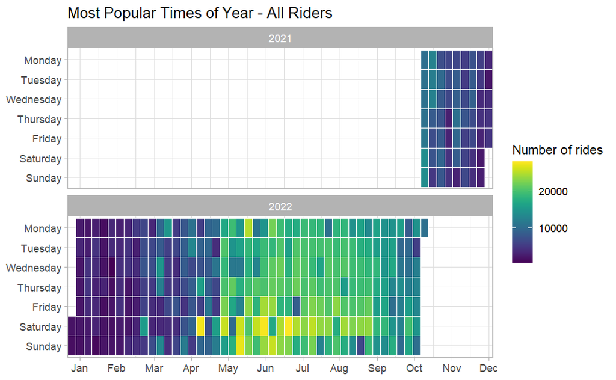

We can see that the summer months are considerably more popular among all riders.

Now, let’s break this down into two separate heat maps - one for casual riders and one for members.

| date | day_of_week | week | year | member_casual | numrides |
| --- | --- | --- | --- | --- | --- |
| 2021-11-01 | Monday | 44 | 2021 | casual | 2572 |
| 2021-11-01 | Monday | 44 | 2021 | member | 7861 |
| 2021-11-02 | Tuesday | 44 | 2021 | member | 8298 |
| 2021-11-02 | Tuesday | 44 | 2021 | casual | 2297 |
| 2021-11-03 | Wednesday | 44 | 2021 | casual | 2325 |
| 2021-11-03 | Wednesday | 44 | 2021 | member | 8342 |

| date | day_of_week | week | year | member_casual | numrides |
| --- | --- | --- | --- | --- | --- |
| 2021-11-01 | Monday | 44 | 2021 | casual | 2572 |
| 2021-11-02 | Tuesday | 44 | 2021 | casual | 2297 |
| 2021-11-03 | Wednesday | 44 | 2021 | casual | 2325 |
| 2021-11-04 | Thursday | 44 | 2021 | casual | 2486 |
| 2021-11-05 | Friday | 44 | 2021 | casual | 3543 |
| 2021-11-06 | Saturday | 44 | 2021 | casual | 6146 |

| date | day_of_week | week | year | member_casual | numrides |
| --- | --- | --- | --- | --- | --- |
| 2021-11-01 | Monday | 44 | 2021 | member | 7861 |
| 2021-11-02 | Tuesday | 44 | 2021 | member | 8298 |
| 2021-11-03 | Wednesday | 44 | 2021 | member | 8342 |
| 2021-11-04 | Thursday | 44 | 2021 | member | 8161 |
| 2021-11-05 | Friday | 44 | 2021 | member | 7860 |
| 2021-11-06 | Saturday | 44 | 2021 | member | 7649 |

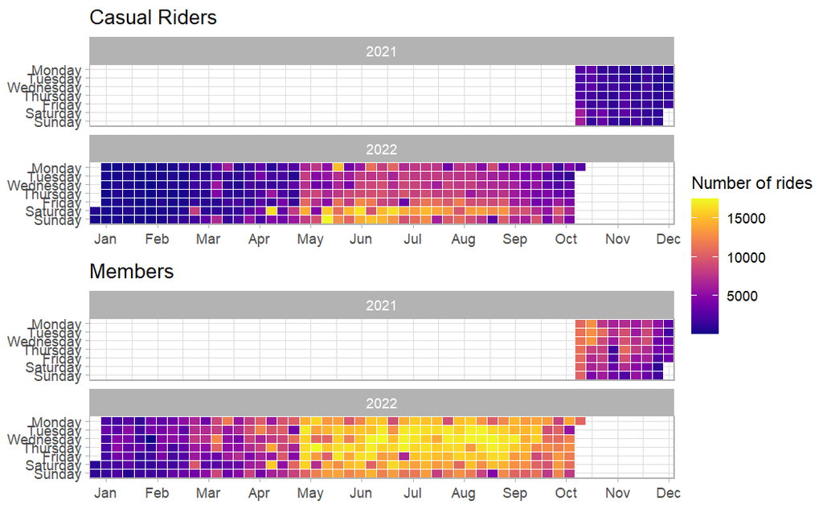

Comparing the two heat maps, we see that members have many more days that have high numbers of rides.

We should focus in on the days that are most popular with casual riders.

So let’s identify the specific dates that are the most popular for casual riders, having at least 10,000 rides.

| member_casual | date | day_of_week | number_of_rides | most_popular |
| --- | --- | --- | --- | --- |
| casual | 2022-04-23 | Saturday | 16336 | * |
| casual | 2022-05-13 | Friday | 10659 |  |
| casual | 2022-05-14 | Saturday | 14150 | * |
| casual | 2022-05-28 | Saturday | 15560 | * |
| casual | 2022-05-29 | Sunday | 17369 | * |
| casual | 2022-05-30 | Monday | 14979 | * |
| casual | 2022-06-03 | Friday | 11103 |  |
| casual | 2022-06-04 | Saturday | 10962 |  |
| casual | 2022-06-05 | Sunday | 12597 |  |
| casual | 2022-06-11 | Saturday | 14751 | * |

[output cut: 27 more lines]

The chart above shows the days of the year that saw the most number of casual rides: 10,000 or more. The “most_popular” column identifies the days that have 14,000 or more casual rides.

When looking at the list, we first will note that all of the dates are on Fridays, Saturdays, Sundays, and Mondays. Fridays and Mondays on the list often correspond with holiday weekends. Certain weekends stand out, such as Memorial Day Weekend (May 28 - 30), Juneteenth Weekend (June 17 - 20), and Fourth of July Weekend (July 2 - 4).

We should tarket these weekends to offer annual membership sales to our casual riders.

### 4. Additional ride data

#### Total Rides by customer type

Now let’s see get a basic look at how many casual and member rides took place and their percentages.

| member_casual | ride_count | percent |
| --- | --- | --- |
| casual | 1741053 | 40 |
| member | 2594348 | 60 |

We can visualize it in a simple pie chart.

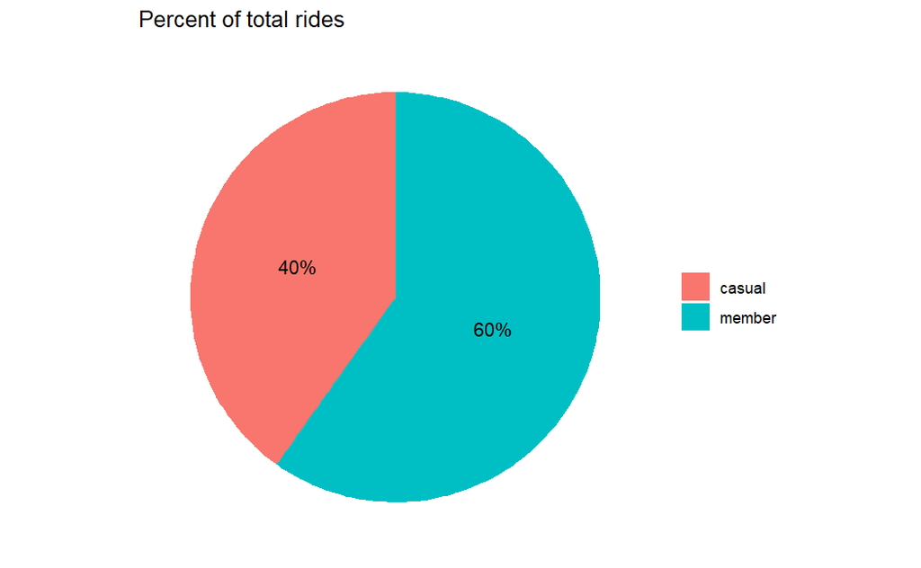

We see that the total number of member rides outnumber the total number of casual rides.

#### Average Duration by customer type

But what about the average length of each ride?

This simple tibble and bar graph shows the average ride length in seconds for casual and member rides.

| member_casual | average_duration_seconds |
| --- | --- |
| casual | 1478 |
| member | 760 |

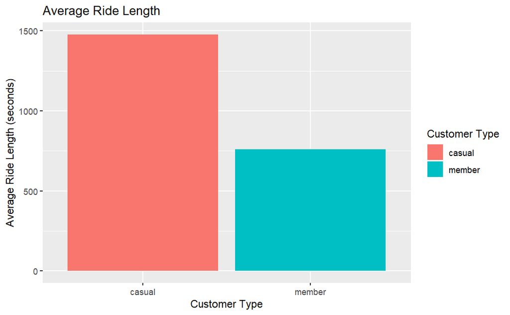

Casual rides are much longer on average than member rides.

#### Analysis per month

Let’s take a closer look at number of rides, breaking it down by months.

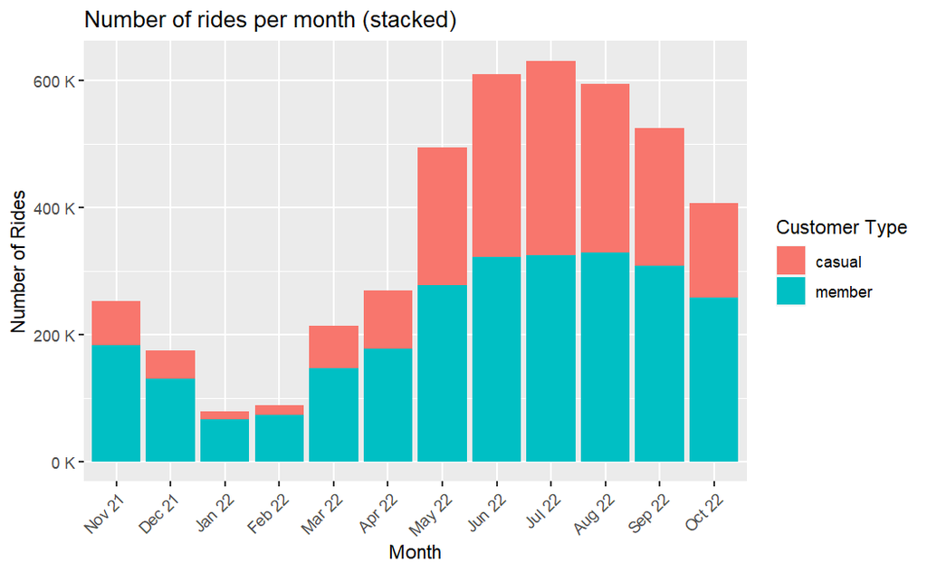

This graph shows the total rides for all customers each month. Each bar represents a month, with the customer type stacked within each month. We can see that the summer months are the most popular.

Now let’s look at the same data in a different way. We will unstack the customer type and put them side-by-side for each month.

| member_casual | month | number_of_rides |
| --- | --- | --- |
| casual | 11 | 69260 |
| casual | 12 | 44673 |
| casual | 1 | 12477 |
| casual | 2 | 14965 |
| casual | 3 | 66370 |
| casual | 4 | 90761 |
| casual | 5 | 216882 |
| casual | 6 | 287423 |
| casual | 7 | 306409 |
| casual | 8 | 265585 |

[output cut: 14 more lines]

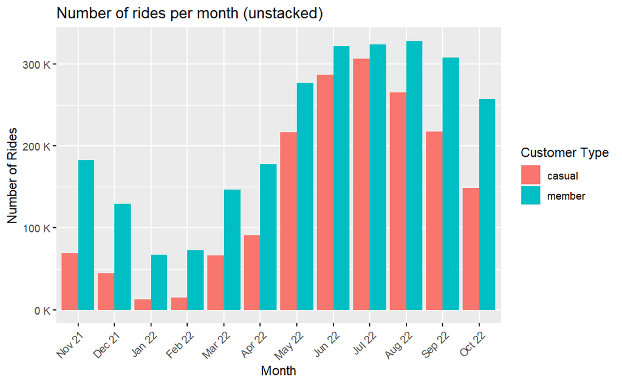

Here we can compare the customer types more closely. Every month has more member rides than casual rides. Also, while member rides remain high June through September, casual rides begin to show decline in August. Winter months have very low ride counts, especially for casual riders.

#### Analysis by Day of the Week

Let’s look at the number of rides and average duration of rides each day of the week.

| member_casual | day_of_week | number_of_rides | average_duration_seconds |
| --- | --- | --- | --- |
| casual | Sunday | 301285 | 1679 |
| casual | Monday | 210967 | 1537 |
| casual | Tuesday | 191954 | 1330 |
| casual | Wednesday | 199204 | 1282 |
| casual | Thursday | 222413 | 1307 |
| casual | Friday | 245923 | 1378 |
| casual | Saturday | 369307 | 1634 |
| member | Sunday | 296982 | 848 |
| member | Monday | 379113 | 733 |
| member | Tuesday | 406522 | 719 |

[output cut: 4 more lines]

This shows the number of rides and the average duration in seconds, respectively, for casual riders and members each day of the week.

Now we will put Number of Rides in a graph.

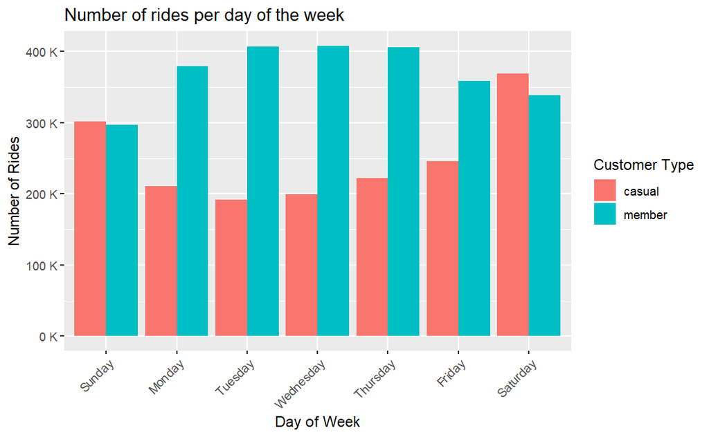

This bar graph shows that the number of rides by members far surpasses those by casual riders on Mondays through Fridays. However, casual rides slightly outnumber member rides on the weekends. The most popular days for members are Tuesday, Wednesday, and Thursday.

Let’s do the same for Average Ride Length.

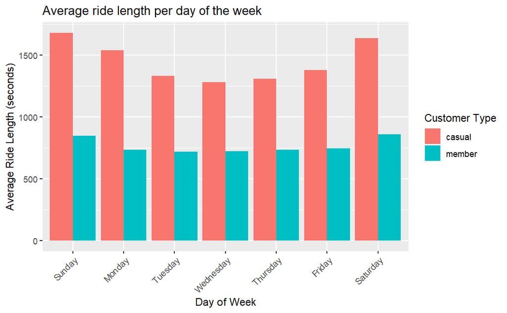

Conversely, this bar graph tells us that the average duration of casual rides is double those of member rides, every day of the week!

A higher average ride length suggests recreational usage of the bike. If this is so, the average casual riders is more likely to use the bikes for recreational purposes. Looking at members, the average duration for members is almost identical Monday through Friday; it is slightly higher for members on the weekends. This suggests that most members use the bikes for commuting to work on the weekdays and for recreation on the weekends.

#### Analysis by time of day

Now, let’s see if there is any difference in the time of day that casual riders and members use Cyclistic bikes.

| member_casual | am_pm_hour | number_of_rides |
| --- | --- | --- |
| casual | 12 AM | 32777 |
| member | 12 AM | 24786 |
| casual | 01 AM | 21020 |
| member | 01 AM | 15276 |
| casual | 02 AM | 12728 |
| member | 02 AM | 8389 |
| casual | 03 AM | 7164 |
| member | 03 AM | 5112 |
| casual | 04 AM | 4635 |
| member | 04 AM | 6036 |

[output cut: 38 more lines]

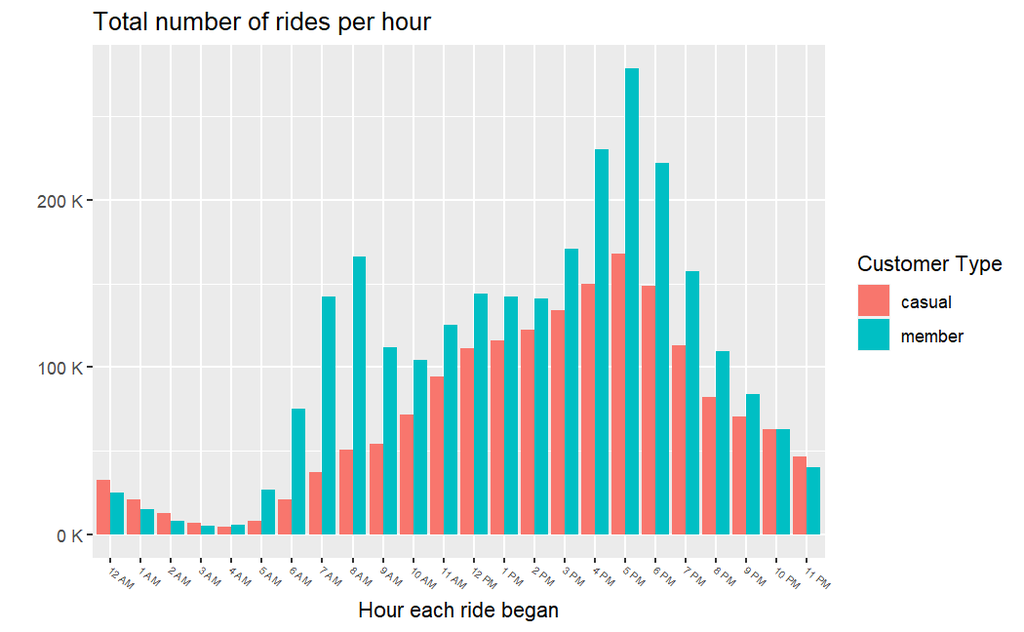

It appears that start time for member rides peaks at around 8am and 5pm. This would be the times that most people leave for and return from work. The start time for casual riders, however, is around 5pm only. This supports the ideas that members use the bikes mostly for work, and casual riders mostly for recreation, as they are getting off of work.

### 5. Summary of Observations and Conclusions:

The most popular bike stations for casual riders are along the coast and the Magnificent Mile, focusing on tourist areas, with the most popular station by far being Streeter Dr and Grand Ave on the Navy Pier. The most popular stations for members are more centrally located around business and residential areas, with the most popular station being Kingsbury St and Kinzie St.

The most popular times of the year are summer weekends and summer holidays. This is especially evident for casual riders.

While the number of member rides outnumber casual rides 3 to 2, the average ride length of casual rides doubles that of member rides.

Summer months are the most popular with all riders. However, members have a “longer” popular summer season (June - September) than casual riders (June - July).

Measuring “popular days” by those with the most number of rides, weekends are the most popular for casual riders. However, the reverse is true for members; weekdays are more popular. But the average ride length is higher on the weekends for both customer types.

As far as start times, member rides peak around 8am and 5pm, about the times that most people leave for work and leave from work. Casual rides peak around 5pm only, suggesting they are most likely to go for a ride after work.

These observations suggest that members use the bikes to travel to work primarily, whereas casual riders use the bikes for recreational purposes mostly.

## IV.Act

What recommendations can we make based on our analysis?

1. Target year-round marketing strategies around popular stations, especially those that are popular for both members and casual riders: Streeter Dr & Grand Ave, DuSable Lake Shore Dr & North Blvd, Wells St & Concord Ln, Clark St & Elm St, Wells St & Elm St, Broadway & Barry Ave, Wabash Ave & Grand Ave.
2. Target seasonal marketing strategies around popular summer holidays: Memorial Day, Juneteenth, and Fourth of July weekends.
3. Advertise the new fleet of electric bikes and the five new charging stations: Bissell St & Armitage Ave, Green St & Randolph St, Lincoln Ave & Roscoe St, Morgan St & Lake St, and Wilton Ave & Diversey Pkwy.